# Vignette: commonweights package

## Package installation

The easiest way to use the `commonweights` package is to install it directly from GitHub:

```r
if(!requireNamespace("remotes")){install.packages("remotes")}
remotes::install_github("BiostatGlobalConsulting/commonweights")
```

Once the package is installed, load it:

```r
library(commonweights)
```

## Harmonia dataset

We’ll use an example dataset with three survey samples from the imaginary country of Harmonia.

```r
data("fauxdata")
```

The dataset includes samples from 2005, 2010, and 2015. In addition to the year variable, the dataset has stratum and cluster IDs, a variable indicating the child’s age in years, the `psweight` variable which shows each child’s survey weight (the number of children in the population represented by this respondent), and three dichotomous variables: possession of a vaccination card, vaccination with DTP3, and vaccination with MCV1.

Here are the first few rows of the faux dataset:

| geo | year | stratumid | clusterid | age | psweight | has_card | dtp3_vx | mcv_vx |
| --- | --- | --- | --- | --- | --- | --- | --- | --- |
| District 01 | 2005 | 1 | 1 | 1 | 3411.063 | 1 | 1 | 1 |
| District 01 | 2005 | 1 | 1 | 1 | 3411.063 | 1 | 0 | 1 |
| District 01 | 2005 | 1 | 1 | 1 | 3411.063 | 1 | 1 | 0 |
| District 01 | 2005 | 1 | 1 | 1 | 3411.063 | 0 | 0 | 1 |
| District 01 | 2005 | 1 | 1 | 1 | 3411.063 | 0 | 0 | 1 |
| District 01 | 2005 | 1 | 1 | 1 | 3411.063 | 1 | 1 | 1 |

## Using the cwt_output function

The core function in the commonweights package is called `cwt_output`. It has the following arguments:

*data* Dataset to analyze. Should have one row per respondent and contain survey data from at least two years.

*outcomevars* Names of dichotomous outcome variable(s) coded 0/1/NA. Provide as a single variable name e.g. “dtp3_vx” or as multiple variables in a concatenated list, e.g. c(“dtp3_vx”, “mcv1_vx”)

*outcomenames* Names of the outcomes in `outcomevars` to use in tables and plots; must be the same length as `outcomevars`. Optional, defaults to NULL. E.g. c(“DTP3”, “MCV1”)

*geovar* Name of geography variable in `data`. Must have the same levels across all years in `years`.

*yearvar* Variable in dataset indicating survey year

*weightvar* Variable in dataset containing survey weights for each respondent

*years* Data years to analyze. Defaults to “all”, which will analyse all years in `yearvar`. To analyze a subset of years, provide a vector of years to include, e.g. c(2000, 2005, 2010)

*weightopt* Which year(s) to use as common weights. “earliest” will calculate outcomes post-stratified to the earliest year in `years`. “previous” will calculate outcomes for each survey year using the weights from the previous survey year. “custom” allows the user to select a year to use weights from.

*weightyear* Year to use for post-stratifying if `weightopt = "custom"`

*age* Age to filter by. Defaults to NULL. Provide as a single value of `agevar` to keep or provide as a pair of values for minimum and maximum ages, e.g. `age = c(12, 23)` will keep `agevar >= 12` and `<= 23`.

*agevar* Age variable in dataset; used if `age` is not NULL. Defaults to NA.

*ci* a logical value indicating whether confidence intervals should be calculated for outcomes. Defaults to FALSE

*cilevel* Defaults to 0.95

*clustvar* Variable in the dataset identifying which cluster each respondent belongs to. Used in confidence interval calculations to take survey design into account. Provide if `ci = TRUE`. Defaults to NULL.

*stratvar* Variable in the dataset identifying which stratum each respondent belongs to. Used in confidence interval calculations to take survey design into account. Provide if `ci = TRUE`. Defaults to NULL.

*countryname* Character, name of the country (or other top-level grouping) that `data` is from

*geolabels* Character vector of labels corresponding to the levels of `geovar`. Defaults to NULL

*palette* Color palette for the levels of `geovar` in output plots. Defaults to NULL, in which case a default ggplot2 palette will be used.

If you don’t want to use the default ggplot2 colors in the subnational weight plot, define a color palette with at least as many levels as your geography variable. The Harmonia dataset has ten districts, so the palette we define should have at least ten colors.

```r
pal <- c("#f7abc1", "#a2d3fa", "#69c9c8", "#f1cfa1", "#a33c51",
         "#ed8e1c", "#298667", "#0d6eba", "#b8f5f2", "#081116")
```

```r
harmonia <- cwt_output(
  data = fauxdata,
  outcomevars = c("has_card", "dtp3_vx", "mcv_vx"),
  outcomenames = c("Vaccination Card", "DTP3", "MCV1"),
  geovar = "geo",
  yearvar = "year",
  weightvar = "psweight",
  years = "all",
  weightopt = "previous",
  age = 1,
  agevar = "age",
  ci = TRUE,
  cilevel = 0.95,
  clustvar = "clusterid",
  stratvar = "stratumid",
  countryname = "Harmonia",
  geolabels = NULL,
  palette = pal
)
```

The `cwt_output` function returns eight kinds of objects:

```
#> weightdata
#> outcomes
#> subnational_outcomes
#> tables
#> weight_plot
#> subnational_outcome_plots
#> national_outcome_plots
#> combined_plots
```

1. `weightdata` is a data frame showing the relative weight for each level of the `geo` variable for each year in the dataset. This table is the basis for the visualization of weights over time in the `weight_plot` output.

| Area | Ratio | Year |
| --- | --- | --- |
| District 01 | 0.1712861 | 2005 |
| District 02 | 0.0502286 | 2005 |
| District 03 | 0.1020732 | 2005 |
| District 04 | 0.0845725 | 2005 |
| District 05 | 0.0884471 | 2005 |
| District 06 | 0.0329965 | 2005 |
| District 07 | 0.1466786 | 2005 |
| District 08 | 0.1901285 | 2005 |
| District 09 | 0.0922602 | 2005 |
| District 10 | 0.0413286 | 2005 |
| District 01 | 0.1938540 | 2010 |
| District 02 | 0.0628090 | 2010 |
| District 03 | 0.1383330 | 2010 |
| District 04 | 0.1052130 | 2010 |
| District 05 | 0.0900840 | 2010 |
| District 06 | 0.0257550 | 2010 |
| District 07 | 0.1150630 | 2010 |
| District 08 | 0.1611790 | 2010 |
| District 09 | 0.0758020 | 2010 |
| District 10 | 0.0319080 | 2010 |
| District 01 | 0.1790042 | 2015 |
| District 02 | 0.0664722 | 2015 |
| District 03 | 0.0970843 | 2015 |
| District 04 | 0.0871811 | 2015 |
| District 05 | 0.1015230 | 2015 |
| District 06 | 0.0269577 | 2015 |
| District 07 | 0.1474668 | 2015 |
| District 08 | 0.1739719 | 2015 |
| District 09 | 0.0919594 | 2015 |
| District 10 | 0.0283794 | 2015 |

2. `outcomes` is a data frame that contains, for each outcome and each year specified in the function call, the point estimate using original weights (`Outcome_Original`), a survey-adjusted Wilson confidence interval for that point estimate (`CI_LB_Original` and `CI_UB_Original`), and the point estimate when weights are post-stratified.

| Country | OutcomeVar | OutcomeName | Outcome_Original | CI_LB_Original | CI_UB_Original | Outcome_PS | DataYear | PSWeightYear |
| --- | --- | --- | --- | --- | --- | --- | --- | --- |
| Harmonia | has_card | Vaccination Card | 75.54276 | 74.02406 | 77.00025 | 75.54276 | 2005 | 2005 |
| Harmonia | dtp3_vx | DTP3 | 59.73118 | 57.02038 | 62.38379 | 59.73118 | 2005 | 2005 |
| Harmonia | mcv_vx | MCV1 | 78.52381 | 76.12740 | 80.74052 | 78.52381 | 2005 | 2005 |
| Harmonia | has_card | Vaccination Card | 76.89244 | 75.29550 | 78.41575 | 76.73117 | 2010 | 2005 |
| Harmonia | dtp3_vx | DTP3 | 57.96189 | 55.98926 | 59.90941 | 60.16968 | 2010 | 2005 |
| Harmonia | mcv_vx | MCV1 | 76.05463 | 74.32533 | 77.70240 | 78.11639 | 2010 | 2005 |
| Harmonia | has_card | Vaccination Card | 77.14849 | 75.29943 | 78.89793 | 77.41822 | 2015 | 2010 |
| Harmonia | dtp3_vx | DTP3 | 59.35863 | 57.36781 | 61.31917 | 58.13668 | 2015 | 2010 |
| Harmonia | mcv_vx | MCV1 | 78.14932 | 76.40031 | 79.80298 | 76.70585 | 2015 | 2010 |

3. `subnational_outcomes` contains subnational outcome estimates for each level of `geovar`. Recall that post-stratifying does not affect outcome estimates at this lower level – it only impacts how the subnational estimates are aggregated to produce a national estimate. So, there are no “original” and “post-stratified” outcome estimates in this table.

| Country | Area | Year | has_card | dtp3_vx | mcv_vx |
| --- | --- | --- | --- | --- | --- |
| Harmonia | District 01 | 2005 | 0.7693386 | 0.3814586 | 0.5869173 |
| Harmonia | District 02 | 2005 | 0.7870275 | 0.5140890 | 0.7206910 |
| Harmonia | District 03 | 2005 | 0.7754494 | 0.5369813 | 0.7289519 |
| Harmonia | District 04 | 2005 | 0.7579622 | 0.4315902 | 0.5843676 |
| Harmonia | District 05 | 2005 | 0.7619990 | 0.5749059 | 0.8173440 |
| Harmonia | District 06 | 2005 | 0.7553032 | 0.6850088 | 0.8693519 |
| Harmonia | District 07 | 2005 | 0.7819530 | 0.6516569 | 0.8451855 |
| Harmonia | District 08 | 2005 | 0.7025332 | 0.7725157 | 0.9143045 |
| Harmonia | District 09 | 2005 | 0.7592444 | 0.7728831 | 0.9620465 |
| Harmonia | District 10 | 2005 | 0.7314426 | 0.6682970 | 0.8986079 |
| Harmonia | District 01 | 2010 | 0.7769372 | 0.4090884 | 0.5558067 |
| Harmonia | District 02 | 2010 | 0.7907080 | 0.4900105 | 0.7523124 |
| Harmonia | District 03 | 2010 | 0.7875062 | 0.5451006 | 0.7298183 |
| Harmonia | District 04 | 2010 | 0.7832280 | 0.4242658 | 0.6020149 |
| Harmonia | District 05 | 2010 | 0.7294830 | 0.5783117 | 0.8405597 |
| Harmonia | District 06 | 2010 | 0.7822653 | 0.6803057 | 0.8418754 |
| Harmonia | District 07 | 2010 | 0.8105942 | 0.6552408 | 0.8216733 |
| Harmonia | District 08 | 2010 | 0.7200087 | 0.7750533 | 0.9177197 |
| Harmonia | District 09 | 2010 | 0.7765690 | 0.7811360 | 0.9600268 |
| Harmonia | District 10 | 2010 | 0.7288904 | 0.6377340 | 0.8967808 |
| Harmonia | District 01 | 2015 | 0.7724839 | 0.3978414 | 0.6111918 |
| Harmonia | District 02 | 2015 | 0.8094974 | 0.5055373 | 0.7084551 |
| Harmonia | District 03 | 2015 | 0.8175516 | 0.5945435 | 0.7390426 |
| Harmonia | District 04 | 2015 | 0.8227012 | 0.4079434 | 0.5576576 |
| Harmonia | District 05 | 2015 | 0.7712527 | 0.5609297 | 0.8353391 |
| Harmonia | District 06 | 2015 | 0.7121252 | 0.6692752 | 0.8990177 |
| Harmonia | District 07 | 2015 | 0.7942318 | 0.6386410 | 0.8248582 |
| Harmonia | District 08 | 2015 | 0.7084574 | 0.7859487 | 0.9180152 |
| Harmonia | District 09 | 2015 | 0.7658981 | 0.7728289 | 0.9622767 |
| Harmonia | District 10 | 2015 | 0.7047152 | 0.6522843 | 0.9072804 |

4. `tables` is a list containing a data frame for each outcome specified. Each row represents a survey pair, and contains original and post-stratified outcome estimates for both years in the survey pair, as well as calculations of relative difference due to state weights (RDSW) and difference-in-differences. `tables` also contains an openxlsx Worksheet object called `excel`, which is ready to export as a spreadsheet; more on that below.

```
#> Harmonia_has_card_table
#> Harmonia_dtp3_vx_table
#> Harmonia_mcv_vx_table
#> excel
```

You can view the individual data frames with syntax like:

```r
harmonia$tables$Harmonia_dtp3_vx_table
```

| Country | OutcomeVar | OutcomeName | l_year | k_year | pl | pk | plps | pkps | poststratyear | pl_minus_pk | plps_minus_pkps | rdsw | diff_in_diffs |
| --- | --- | --- | --- | --- | --- | --- | --- | --- | --- | --- | --- | --- | --- |
| Harmonia | dtp3_vx | DTP3 | 2010 | 2005 | 57.96189 | 59.73118 | 60.16968 | 59.73118 | 2005 | -1.769292 | 0.4385004 | 124.78395 | 2.207792 |
| Harmonia | dtp3_vx | DTP3 | 2015 | 2010 | 59.35863 | 57.96189 | 58.13668 | 57.96189 | 2010 | 1.396742 | 0.1747930 | 87.48567 | -1.221949 |

You can save the Excel object - basically, formatted versions of the individual outcome tables - with syntax like the following:

```r
openxlsx::saveWorkbook(harmonia$tables$excel, file = "HarmoniaTables.xlsx")
```

The Excel spreadsheet will have a tab for each outcome.

5. `weight_plot` is a plot showing how subnational weights change over time.

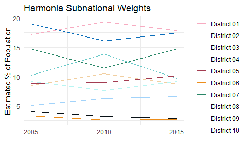

6. `subnational_outcome_plots` is a list of plots, each showing outcomes in each geographic area over time.

For example, to look at the plot for DTP3 coverage by district:

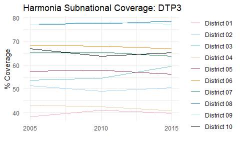

```r
harmonia$subnational_outcome_plots$subnational_plot_dtp3_vx
```

7. `national_outcome_plots` is a list of plots, each showing original and post-stratified outcomes over time.

For example, to look at the plot for MCV1 coverage:

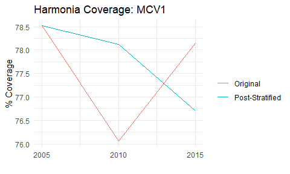

```r
harmonia$national_outcome_plots$national_plot_mcv_vx
```

8. `combined_plots` aggregates `weight_plot` and the subnational and national plots for each outcome. The weight and subnational outcome plots help put the plot of original and post-stratified outcomes in context. There is one combined plot for each outcome variable.

You can display these plots with `grid::grid.draw` to view in an R session:

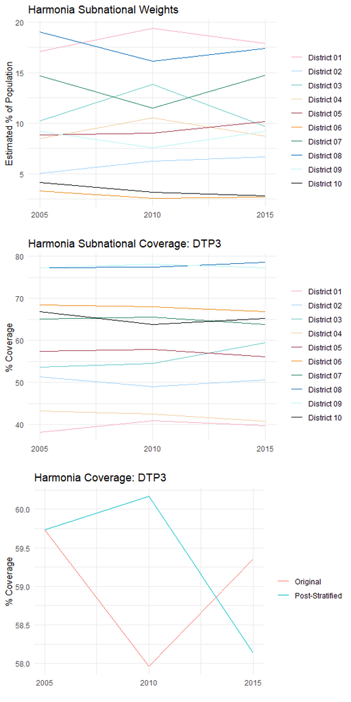

```r
grid::grid.draw(harmonia$combined_plots$combined_plot_dtp3_vx)
```

Or you can save the combined plots with ggsave:

```r
ggplot2::ggsave("CombinedPlotDTP3.png"
       harmonia$combined_plots$combined_plot_dtp3_vx,
       height = 12, width = 6, units = "in")
```